# Introduction to

## Leaves, intermediates, inplace and ...

There roughly are these types of tensors from an autograd perspective:

- "Plain" tensors, not requiring gradients (in particular all integral tensors).
- Leaves are the initial tensors requiring grad, from the factory functions or by taking a non-grad-requiring tensor and saying `t.requires_grad_()`.
- Computed tensors where an input requires gradients will, in general, require gradient.
- "views", tensors sharing memory, are special.

Let's look at this in some detail.

```python
a = torch.randn(5, requires_grad=True)
b = torch.randn(5, requires_grad=True)
c = (a + 1) * b
ptgraph(c)
```

[figure not shown]

A common mistake is to accidentally throw away the true leaf. Note the difference between `a` and `b`.

```python
a = torch.randn(5, requires_grad=True).cuda()
b = torch.randn(5, requires_grad=True, device='cuda')
c = (a + 1) * b
ptgraph(c)
```

[figure not shown]

This would be a repaired version (but, if you can, working directly on the GPU is more efficient).

```python
a = torch.randn(5).cuda().requires_grad_()
b = torch.randn(5, requires_grad=True, device='cuda')
c = (a + 1) * b
ptgraph(c)
```

[figure not shown]

You can cut things from autograd with `detach()` (and `detach_()`)

```python
a = torch.randn(5, requires_grad=True).cuda()
b = torch.randn(5, requires_grad=True, device='cuda')
c = (a + 1).detach() * b
ptgraph(c)
```

[output not shown]

Inplace with autograd can be tricky

```python
a = torch.randn(5, requires_grad=True)
b1 = a + 1
b2 = b1 + 1

b1 += 1

torch.autograd.grad(b2.sum(), a) # works
```

```
(tensor([1., 1., 1., 1., 1.]),)
```

```python
a = torch.randn(5, requires_grad=True)
b1 = a + 1
b2 = b1 ** 2
b1 += 1

torch.autograd.grad(b2.sum(), a) # this would need the original b1
```

```
---------------------------------------------------------------------------
RuntimeError                              Traceback (most recent call last)
<ipython-input-35-950f59f473fd> in <module>
      4 b1 += 1
      5
----> 6 torch.autograd.grad(b2.sum(), a) # this would need the original b1

/usr/local/lib/python3.8/dist-packages/torch/autograd/__init__.py in grad(outputs, inputs, grad_outputs, retain_graph, create_graph, only_inputs, allow_unused)
    188         retain_graph = create_graph
    189
--> 190     return Variable._execution_engine.run_backward(
    191         outputs, grad_outputs, retain_graph, create_graph,
    192         inputs, allow_unused)

RuntimeError: one of the variables needed for gradient computation has been modified by an inplace operation: [torch.FloatTensor [5]], which is output 0 of AddBackward0, is at version 1; expected version 0 instead. Hint: enable anomaly detection to find the operation that failed to compute its gradi…
```

We did not get a TraceBack in Jupyter before PyTorch 1.7 (PR #41116), but now we get too much (the crucial `b2 = b1 ** 2` is there, but off-screen)...

```python
with torch.autograd.detect_anomaly():
    a = torch.randn(5, requires_grad=True)
    b1 = a + 1
    b2 = b1 ** 2
    b1 += 1

    torch.autograd.grad(b2.sum(), a) # this would need the original b1
```

[output not shown]

[output cut: 14 more lines]

[output not shown]

```
---------------------------------------------------------------------------
RuntimeError                              Traceback (most recent call last)
<ipython-input-36-fb1eaba42148> in <module>
      5     b1 += 1
      6
----> 7     torch.autograd.grad(b2.sum(), a) # this would need the original b1

/usr/local/lib/python3.8/dist-packages/torch/autograd/__init__.py in grad(outputs, inputs, grad_outputs, retain_graph, create_graph, only_inputs, allow_unused)
    188         retain_graph = create_graph
    189
--> 190     return Variable._execution_engine.run_backward(
    191         outputs, grad_outputs, retain_graph, create_graph,
    192         inputs, allow_unused)

RuntimeError: one of the variables needed for gradient computation has been modified by an inplace operation: [torch.FloatTensor [5]], which is output 0 of AddBackward0, is at version 1; expected version 0 instead. Hint: the backtrace further above shows the operation that failed to compute its grad…
```

There are some opportunities where inplace is actually very useful. One of my faviourite tricks is to copy things into a preallocated tensor.

```python
a = torch.randn(5, requires_grad=True)
b = torch.randn(5, requires_grad=True)
c = torch.zeros(4, 7)  # padded torch.stack([a,b])
c[1, 1:-1] = a
c[2, 1:-1] = b
c
```

```
tensor([[ 0.0000,  0.0000,  0.0000,  0.0000,  0.0000,  0.0000,  0.0000],
        [ 0.0000,  0.0539,  0.2435, -0.3037, -0.2411, -0.0319,  0.0000],
        [ 0.0000,  0.7659,  1.2740,  0.2249, -1.1687, -1.7693,  0.0000],
        [ 0.0000,  0.0000,  0.0000,  0.0000,  0.0000,  0.0000,  0.0000]],
       grad_fn=<CopySlices>)
```

```python
gr_a, gr_b = torch.autograd.grad(c.sum(), [a, b])
assert (gr_a -1).abs().max().item() < 1e-6 and (gr_b -1).abs().max().item() < 1e-6  # float and "==" don't mix well
```

## Inplace Summary

There are two main situations where inplace operations cannot be used:

- When operating on leaf tensors, the leaf tensor would be moved into the graph, which would be bad.
- When the operation before the inplace wants to have its result to compute the backward. Whether this is the case is not easy to tell from the outside, unfortunately.

As a corollary, you should avoid using inplace on the inputs of your re-usable module lest in the future use could be in one of the two situations.

Later: You might also be less eager to use inplace when planning to use the JIT, as it will fuse pointwise non-inplace operations like ReLU if there are several in a row.

For validation, inference or other things where the *end user* decides she does not want gradients, there is the `torch.no_grad` context manager.

We'll use it below to evaluate models after training.

- If you need to use `torch.no_grad()` somewhere where it isn’t because you’re evaluating something that’s written for training, you should ask yourself if you’re doing it wrong.
- Using item and detach for things to keep around longer than the next backward is generally a good idea (e.g. when you record loss history, statistics, …), but be careful to not ruin your graph. (Targeted detach is good in nn.Module subclass code, with torch.no_grad() should be needed very rarely.)

It is not true that tensors created in `torch.no_grad` never require grad (as often views are special):

```python
a = torch.randn(5, 5, requires_grad=True)

with torch.no_grad():
    b = a * 2
    c = a[:2, :2]

b, c
```

```
(tensor([[ 4.5442,  2.7897, -2.8073,  1.9178,  2.6865],
         [-0.4001, -1.4518,  2.4382,  4.3330,  2.4355],
         [-1.9214, -0.5341,  2.4665, -3.8517,  3.4939],
         [ 0.3584,  1.1731,  1.1691, -3.1120, -0.5954],
         [ 0.7143, -0.2832, -1.8675, -3.3314, -0.5892]]),
 tensor([[ 2.2721,  1.3948],
         [-0.2001, -0.7259]], requires_grad=True))
```

### Second derivatives

You cannot get Hessians, but you can get Hessian vector products or really derivatives of any scalar function of the gradient.

```python
a = torch.arange(5., requires_grad=True)
b = a ** 4
gr, = torch.autograd.grad(b.sum(), [a], create_graph=True)
hvp, = torch.autograd.grad(gr.sum(), [a])  # what is the vector in HVP?
a, hvp # 4 * 3 * x
```

```
(tensor([0., 1., 2., 3., 4.], requires_grad=True),
 tensor([  0.,  12.,  48., 108., 192.]))
```

## `backward` as a convenience method

Above we used `torch.autograd.grad`. More commonly, you find `loss.backward()`. This is a convenience method for computing the gradient of all leaves `t` and storing the gradient in `t.grad`. In particular, PyTorch's built-in optimizers use these.

You can ask for a gradient of an intermediate to be stored by `t.retain_grad()`.

My advice: Only use backward to get gradients to then use with the optimizer. Don't use backward with `create_graph`.

## A fun trick

Sometimes, we want the backward to not quite be like the forward. Round obviously has gradient 0, but wouldn't it be sometimes be convenient if...

```python
a = torch.randn(5, requires_grad=True)
b = a.round()
gr, = torch.autograd.grad(b.sum(), [a])
gr
```

```
tensor([0., 0., 0., 0., 0.])
```

...we can actually do that (not this construction, but the same rounding trick is the gist of "quantization aware training", other things like "gumble softmax" also work like this):

```python
def differentiable_round(a, ndigits=None):
    if ndigits is None:
        b = a.round()
    else:
        scale = 10 ** ndigits
        b = (a * scale).round() / scale
    return a + (b - a).detach()  # PyTorch's version of "cleverly add 0"
c = differentiable_round(a)
gr2, = torch.autograd.grad(c.sum(), [a])
(c == b).all().item(), gr2
```

```
(True, tensor([1., 1., 1., 1., 1.]))
```

Fake quantization training the hard way

```python
w1 = torch.randn(1, 10, requires_grad=True)
b1 = torch.randn(10, requires_grad=True)
w2 = torch.randn(10, 1, requires_grad=True)
b2 = torch.randn(1, requires_grad=True)
params = [w1, b1, w2, b2]


for i in range(200):
    x = torch.randn(10, 1)
    target = torch.sin(2 * x)

    xr = differentiable_round(x)
    w1r = differentiable_round(w1, 0.5)
    b1r = differentiable_round(b1, 0.5)
    w2r = differentiable_round(w2, 0.5)
    b2r = differentiable_round(b2, 0.5)
    pred = torch.tanh(xr @ w1r + b1r) @ w2r + b2r

    loss = ((pred - target) ** 2).sum()

    grads = torch.autograd.grad(loss, params)

    for p, g in zip(params, grads):
        with torch.no_grad():
            p -= 1e-2 * g
```

Did it work?

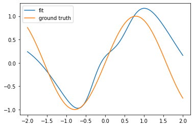

```python
with torch.no_grad(): # no gradients here...
    w1r = differentiable_round(w1, 0.5)
    b1r = differentiable_round(b1, 0.5)
    w2r = differentiable_round(w2, 0.5)
    b2r = differentiable_round(b2, 0.5)
    x0 = torch.linspace(-2, 2)
    final_preds = torch.tanh(x0[:, None] @ w1r + b1r) @ w2r + b2r
    gt = torch.sin(2*x0)

pyplot.plot(x0, final_preds, label='fit')
pyplot.plot(x0, gt, label='ground truth')
pyplot.legend()
```

## Own Autograd functions

Let's consider $f : \mathbb{R}^n \rightarrow \mathbb{R}^m$ implicitly given by $F(x,f(x))=0$ for some function $F : \mathbb{R}^n \times \mathbb{R}^m \rightarrow \mathbb{R}$.

For nice (smooth, nondegenerate) functions, the [implicit function theorem](https://en.wikipedia.org/wiki/Implicit_function_theorem) gives us:

Given $x,y$ such that $F(x,y) = 0$ there is a neighborhood $U\ni x$ and a function $f$ such that $f(x)=y$ and $F(x,f(x))=0$. And if $F$ is nice enough, we can also compute the derivative of $f$ at $x$, namely $\frac{df}{dx}(x) = - (\frac{dF}{dy}(x,y))^{-1} \frac{dF}{dx}(x,y)$.

Given $F$ in PyTorch, can we define $f$ and backpropagate through the computation?

$\Rightarrow$ Need to extend autograd.

```python
class Implicit(torch.autograd.Function):  # derive autograd.Function
    @staticmethod
    def forward(ctx, x, y0, F, max_iter=100):  # Context ctx as special first parameter to static method forward
        with torch.enable_grad():
            y = y0.clone().detach().requires_grad_()
            xv = x.detach()
            opt = torch.optim.LBFGS([y], max_iter=max_iter)  # numerical search for y s.t. F(x, y) = 0
            def reevaluate():
                opt.zero_grad()
                z = F(xv,y)**2
                z.backward()
                return z
            opt.step(reevaluate)
        ctx._the_function = F                 # save non-tensors
        ctx.save_for_backward(x, y)           # safely save tensors
        return y
    @staticmethod
    def backward(ctx, output_grad):          # ouput_grad = dl / dy
        x, y = ctx.saved_tensors             # get the saved tensors
        F = ctx._the_function                # other arguments
        with torch.enable_grad():
            xv = x.detach().requires_grad_()
            y = y.detach().requires_grad_()
            z = F(xv,y)
            z.backward()
        return -xv.grad/y.grad*output_grad, None, None, None  # return dl / dx and None for all other inputs
```

Let's try it on a simple case:

```python
def circle(x,y):
    return x**2+y**2-1  # 0-set = unit circle

x = torch.tensor([0.5], dtype=torch.double, requires_grad=True)
y0 = torch.tensor([0.5], dtype=torch.double) # starting value
y= Implicit.apply(x, y0, circle)    # this is how to use our new function
print (y, (1-0.5**2)**0.5)
gr, = torch.autograd.grad(y, x)
gr_exp, = torch.autograd.grad((1-x**2)**0.5, [x])
gr, gr_exp
```

```
tensor([0.8660], dtype=torch.float64, grad_fn=<ImplicitBackward>) 0.8660254037844386
```

```
(tensor([-0.5774], dtype=torch.float64),
 tensor([-0.5774], dtype=torch.float64))
```

We could now backpropagate through it, too.

# PyTorch is ... a Neural Network (and general Modelling) Library

`torch.nn.Module` and subclasses play the central role as Neural Network building blocks. Modules are for bundling neural network *state*, i.e. Parameters, other Buffers, Submodules, with the rules to compute outputs from inputs.

- Parameters: wrap in torch.nn.Parameter + assign
- Buffers (Tensors noch trained via SGD, e.g. statistics): register_buffer
- Submodules: assign

Here is the equivalent of our previous model:

```python
class MyModel(torch.nn.Module):
    def __init__(self):
        super().__init__()
        self.w1 = torch.nn.Parameter(torch.randn(1, 10))
        self.b1 = torch.nn.Parameter(torch.randn(10))
        self.w2 = torch.nn.Parameter(torch.randn(10, 1))
        self.b2 = torch.nn.Parameter(torch.randn(1))

    def forward(self, x):
        return torch.tanh(x @ self.w1 + self.b1) @ self.w2 + self.b2

model = MyModel()
model.to(device="cuda")
model.w1
```

```
Parameter containing:
tensor([[ 1.1177,  1.2803, -3.9744, -2.1031, -1.7723, -0.8169,  0.2313,  1.3349,
         -0.5564, -0.0529]], device='cuda:0', requires_grad=True)
```

A rich library of pre-made modules under `torch.nn`.

- `torch.nn.Linear`, `Conv2d`, `MaxPool2D`, `Tanh`, ... Also loss functions:
- `CrossEntropyLoss`, `MSELoss`, `CTCLoss`...

Careful: Naming `CrossEntropyLoss` vs. `NLLLoss` etc. is particular to PyTorch. Check the documentation for PyTorch's expectation of whether input have `softmax` / `log_softmax` / something else applied.

We can make our model again with these:

```python
class MyModel(torch.nn.Module):
    def __init__(self):
        super().__init__()
        self.l1 = torch.nn.Linear(1, 10)
        self.l2 = torch.nn.Linear(10, 1)

    def forward(self, x):
        x = torch.tanh(self.l1(x))
        return self.l2(x)

model = MyModel()
model
```

```
MyModel(
  (l1): Linear(in_features=1, out_features=10, bias=True)
  (l2): Linear(in_features=10, out_features=1, bias=True)
)
```

There also is a `Sequential` class for particularly simple "chains" of modules (with only one input/output).

```python
model = torch.nn.Sequential(
            torch.nn.Linear(1, 10),
            torch.nn.Tanh(),
            torch.nn.Linear(10, 1))

inp = torch.randn(5, 1, requires_grad=True)
res = model(inp)
ptgraph(res)
```

[figure not shown]

Task: Can you subclass sequential to get a model class?

### Loading and Saving models

While you can save and load models using `torch.save` and `torch.load`, it is generally not recommended.

Instead, save the state dict and upon loading instantiate the model and load the state dict. This is much better for forward compatibility.

```python
torch.save(model.state_dict(), 'saved_model.pt')
sd = torch.load('saved_model.pt')
model.load_state_dict(sd)
```

```
<All keys matched successfully>
```

## Some thoughts on functional vs. Module

- If you write for re-use, the functional / Module split of PyTorch has turned out to be a good idea.
- Use functional for stuff without state (unless you have a quick and dirty Sequential).
- Never re-use modules (define one `torch.nn.ReLU` and use it 5 times). It's a trap!

  When doing analysis or quantization (when `ReLU` becomes stateful due to quantization params), this will break.

# PyTorch has ... optimizers

In `torch.optim`.

- Most common probably: `torch.optim.SGD`, `torch.optim.Adam`, but also `torch.optim.LBFGS` etc.
- Schedules for the learning are also available.

Pattern:

- `loss = ...`
- `opt.zero_grad()`
- `loss.backward()`
- `opt.step()`

Optimizers also have a `state_dict` for saving / restoring.

Let's see that in action with our toy model:

```python
model = torch.nn.Sequential(
            torch.nn.Linear(1, 10),
            torch.nn.Tanh(),
            torch.nn.Linear(10, 1))

opt = torch.optim.SGD(model.parameters(), lr=1e-2)

for i in range(200):
    x = torch.randn(10, 1)    # input  from dataset
    target = torch.sin(2 * x) # target from dataset

    pred = model(x)
    loss = torch.nn.functional.mse_loss(pred, target, reduction='sum')

    opt.zero_grad()
    loss.backward()
    opt.step()
```

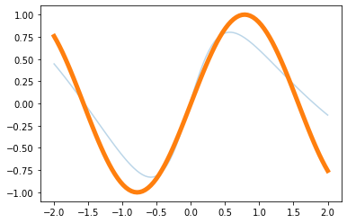

```python
with torch.no_grad():
    x0 = torch.linspace(-2, 2)
    pyplot.plot(x0, model(x0[:, None]).detach(), alpha=0.3)
    pyplot.plot(x0, torch.sin(2 * x0), linewidth=5)
```

# PyTorch has ... utilities for data handling

PyTorch splits data handling in two parts:

- Problem specific (DataSet)
- Generic, e.g. Sampling, Batching (DataLoader)

User's responsibility: Define `torch.utils.data.DataSet` subclass with

- a `__len__` method (how many data points)
- a `__getitem__` method to get the `i`th element, returning tuples of numbers and tensors

`DataLoader` is more or less universal. In several parallel processes, get items from dataset and assemble them into batches (for numbers, tensors, make tensors, for other things, lists).

Let's try that:

```python
import torch.utils.data
class DS(torch.utils.data.Dataset):
    def __init__(self, shape):
        self.shape = shape
    def __len__(self):
        return 100
    def __getitem__(self, i):
        return (i % 10 + torch.randn(self.shape), i % 10) # observation and label

ds = DS((5,))
dl = torch.utils.data.DataLoader(ds, batch_size=8, shuffle=True)

for inp, label in dl:
    print(inp, label)
    break
```

```
tensor([[ 9.5571,  7.1095,  7.1393,  7.4666,  6.7035],
        [ 5.3171,  9.0150,  6.7444,  7.5128,  5.4807],
        [ 9.7531,  7.9709,  8.2818, 10.1165, 10.7010],
        [-1.1085,  1.3127,  0.5249,  1.1068, -0.7207],
        [ 1.0284,  0.7190,  3.0181,  3.5250,  3.3695],
        [ 3.6932,  0.9453,  1.3540,  0.8289,  0.6140],
        [ 5.3443,  3.6160,  5.4480,  5.8480,  4.3890],
        [ 1.3029,  1.7199,  0.7438,  0.8375,  2.5249]]) tensor([7, 7, 9, 0, 2, 1, 5, 1])
```

What happened here?

The DataLoader provides an iterator and for each iteration

- requested elements from the dataset,
- took the 1d `5`-tensors and `stack`ed them to a 2d `batchsize x 5` tensor,
- took the integers and put them into a 1d `batchsize` tensor.
- gives the tuple of input and label to the for loop.

**Good to know**: If `batchsize` does not divide `len(ds)`, the last batch will be shorter. This can be troublesome (e.g. batch norm running with a batch size of 1), so you have the `drop_last` optional command to just skip this minibatch.

### Performance of the DataLoader

Using `Dataset` / `DataLoader` is simple, but keep in mind that it can greatly impact performance.

How do you detect this? If, during training, your GPU is not constantly fully used (shown by `*smi` tools), you have a CPU bottleneck somewhere, and the data loading is one thing to check.

- If more cores help, there is the `num_workers` argument to the dataloader.
- Get a SSD.
- If you can do preprocessing beforehand (no augmentation), try that. (But careful, I/O is often more expensive than processing.)
- If you can do preprocessing on the GPU instead (augmentation in particular), do that.
- Sometimes it helps to put tensors into *GPU pinned memory*, with the `pin_memory` argument for the DataLoader.

# Excursion: GPU, efficiency, measurement

One of my informal mottos is *It's not optimization until you measure*. I'll only discuss the most basic measurement here, PyTorch offers a capable profiling facility, too.

When you think about code being slow, it's important to figure out what is slow and why. To my mind, a lot of measurement can be done with very basic tools, e.g. IPython's `%timeit` magic.

As GPU computation is and shold be ansynchronous, avoid unneeded synchronization points. Synchronization happens when the CPU waits for the GPU (to get the results).

- Synchronizations can happen because the program needs to know something (e.g. sizes of tensors depending on the input). Often, these are unavoidable.
- Typical sources of spurious synchronizations are too frequent `.to(device="cpu")`, `.item()`, `.to_list()`, `print`.

If we want to time GPU kernels, we want to be sure to synchronize before taking the start and end times. Typically, we also want to have some "warm-up", i.e. run the measured function before timing.

Let's take the uniformity loss from [Wang and Isola: Understanding Contrastive Representation Learning through Alignment and Uniformity on the Hypersphere](https://arxiv.org/abs/2005.10242) (a great paper!).

The Uniformity loss is defined as a function of the pairwise distances over a largish set of vectors.

```python
def lunif(x, t=2): # copied from the paper
    sq_pdist = torch.pdist(x, p=2).pow(2)
    return sq_pdist.mul(-t).exp().mean().log()

x = torch.randn(1024, 128, device="cuda")
x /= x.norm(p=2, dim=1, keepdim=True).requires_grad_()

lunif(x)
```

```
tensor(-3.9367, device='cuda:0', grad_fn=<LogBackward>)
```

One would think that the specialised `pdist` function is the right tool for the job. But is it? Let's time it.

```python
def totime(fn):
    l = fn(x)
    g, = torch.autograd.grad(l, x)
    torch.cuda.synchronize()

totime(lunif) # warmup
%timeit totime(lunif)
```

```
19.4 ms ± 103 µs per loop (mean ± std. dev. of 7 runs, 100 loops each)
```

Let's use $|x-y|^2 = |x|^2 + |y|^2 - 2 <x, y>$ and compare.

```python
def lunif2(x, t=2):
    t=2
    xnorm = torch.norm(x, p=2, dim=1).pow(2)
    sq_pdist = xnorm[None] + xnorm[:, None] - 2 * torch.mm(x, x.t())
    exp = sq_pdist.mul(-t).exp().tril(diagonal=-1)
    N = x.size(0)
    res = exp.sum().mul(2/(N*N-N)).log()
    return res

print((lunif2(x.to(torch.double)) - lunif(x.to(torch.double))).item())

totime(lunif2)
%timeit totime(lunif2)
```

```
9.313225746154785e-10
2.26 ms ± 16.8 µs per loop (mean ± std. dev. of 7 runs, 100 loops each)
```

Even though we have stark inefficiencies (like taking tril and taking a copy to do so), this is almost an order of magnitude faster!

Largely due to backward of `pdist` implementation.

## But Python is slow...

Uniformity loss: "what formulas you use" is the real bottleneck (unless you optimize pdist).

The "what" typically should be the first optimization target.

But when we fix the task ("what"), how can we optimize?

Conventional wisdom: **Python is slow**

- certainly, Python isn't fast (`for` loop vs C++ `for` loop)
- but, if the GPU is saturated $\Rightarrow$ Python isn't the bottleneck

### How PyTorch programs spend their time

At a very high level, you can divide time spent into these parts:

- Python program flow,
- Data "administrative overhead" (creating `Tensor` data structures, autograd `Node`s etc.),
- Data aquisition (I/O),
- Computation roughly as
  - fixed overhead (kernel launches etc.),
  - reading / writing memory,
  - "real computation".

**Thomas' rule of thumb**: As long as your operands are reasonably large (say 100s of elements, not single elements), Python and Data "administrative overhead" probably isn't your main problem.

## Optimization potentials

remember that modelling does have a huge lever regarding efficiency

| Millions of parameters vs. timeline for the popular transformer models |  |
| --- | --- |
| Source: V. Sanh (Huggingface), DistilBERT | Source: M. Tan, Q. Le: EfficientNet: Rethinking Model Scaling for Convolutional Neural Networks |

# The PyTorch JIT

So if we have our model in PyTorch. Can we export it?

This is where the PyTorch Just-In-Time compiler comes into play. It provides a graphical representation called *TorchScript* (used somewhat synonymously for the language and the representation).

There are two main ways to get a TorchScript graph:

- scripting and
- tracing.

We'll look at these in some detail.

## Scripting

Scripting compiles (mostly) a subset of Python. It takes the Python source code and transforms it. "Here is what the function should do", just like normal programming.

```python
@torch.jit.script
def fn(x):
    return x * 2
```

```python
fn, fn.graph
```

```
(<torch.jit.ScriptFunction at 0x7f65d43b2220>,
 graph(%x.1 : Tensor):
   %2 : int = prim::Constant[value=2]() # <ipython-input-57-6dcc6c3c1c8e>:3:15
   %3 : Tensor = aten::mul(%x.1, %2) # <ipython-input-57-6dcc6c3c1c8e>:3:11
   return (%3))
```

### Tracing

Tracing runs the code and observers the calls into PyTorch with some sample input. "Watch me, now you know how to do the same."

```python
def fn(x):
    return x * 2
fn = torch.jit.trace(fn, [torch.randn(5)])

print(fn.graph, fn.code)
```

```
graph(%x : Float(5:1)):
  %1 : Long() = prim::Constant[value={2}]() # <ipython-input-59-7d43d0af2e80>:2:0
  %2 : Float(5:1) = aten::mul(%x, %1) # <ipython-input-59-7d43d0af2e80>:2:0
  return (%2)
 def fn(x: Tensor) -> Tensor:
  return torch.mul(x, CONSTANTS.c0)
```

N.B.: The specialization for the Tensor shape isn't relevant here and will be erased e.g. during saving of the model.

### TorchScript

One important difference between TorchScript and Python is that in TorchScript everything is typed. Important types are

- `bool`, `int`, `long`, `double` for numbers (int = 32 bit integer, long = 64 bit integer)
- `Tensor` for tensors (of arbitrary shape, dtype, ...)
- `List[T]` a list with elements fo type T (one of the above)
- Tuples are of fixed size with arbitrary but fixed element type, so e.g. `Tuple(Tensor, int)`.
- `Optional[T]` for things that can be `None`

`None` always is of type `Optional[T]` for some specific `T` (except in the rarest circumstances).

PyTorch will mostly infer the intermediate and return types, but you need to annotate any non-Tensor inputs.

### Tracing vs. Scripting

Scripting will process all code but may not understand all. This means it captures all constructs (like control flow) it understands, but it will fail if it doesn't understand something.

Tracing doesn't see anything not calling into PyTorch and will happily ignore that (e.g. control flow). This is also the reason why it will loudly complain if you have non-tensor inputs.

```python
def fn(x):
    for i in range(x.dim()):
        x = x * x
    return x

script_fn = torch.jit.script(fn)
trace_fn = torch.jit.trace(fn, [torch.randn(5, 5)])
```

```python
print(script_fn.code)
```

```
def fn(x: Tensor) -> Tensor:
  x0 = x
  for i in range(torch.dim(x)):
    x0 = torch.mul(x0, x0)
  return x0
```

```python
print(trace_fn.code)
```

```
def fn(x: Tensor) -> Tensor:
  x0 = torch.mul(x, x)
  return torch.mul(x0, x0)
```

## Tracing and Scripting Modules

But our models often are not functions. What now?

With tracing, we can work just like with functions. We get a `ScriptModule` subclass that behaves much like a `Module` with parameters, state dict etc.

```python
traced_model = torch.jit.trace(model, [torch.randn(8, 1)])
type(traced_model), traced_model
```

```
(torch.jit._trace.TopLevelTracedModule,
 Sequential(
   original_name=Sequential
   (0): Linear(original_name=Linear)
   (1): Tanh(original_name=Tanh)
   (2): Linear(original_name=Linear)
 ))
```

Saving is a bit different, here we include the model on purpose:

```python
traced_model.save('./traced_model.pt')
loaded_model = torch.jit.load('./traced_model.pt')

loaded_model(torch.randn(8,1))
```

```
tensor([[-0.8112],
        [ 0.3232],
        [ 0.7830],
        [-0.8254],
        [ 0.7857],
        [-0.3138],
        [-0.7612],
        [ 0.5701]], grad_fn=<DifferentiableGraphBackward>)
```

# Scripting Modules

Scripting modules is ... a bit tricky. We don't script the class in its entirety but instead take an instance (in particular past `__init__`) and process its data members and methods (the latters work like script functions).

```python
scripted_model = torch.jit.script(model)
print(scripted_model.code)
```

```
def forward(self,
    input: Tensor) -> Tensor:
  _0 = getattr(self, "0")
  _1 = getattr(self, "1")
  _2 = getattr(self, "2")
  input0 = (_0).forward(input, )
  input1 = (_1).forward(input0, )
  return (_2).forward(input1, )
```

We can also look at the graph including submodules, but it gets unwieldy rather fast:

```python
scripted_model.forward.inlined_graph
```

```
graph(%self : __torch__.torch.nn.modules.container.___torch_mangle_13.Sequential,
      %input.1 : Tensor):
  %2 : __torch__.torch.nn.modules.linear.___torch_mangle_10.Linear = prim::GetAttr[name="0"](%self)
  %3 : __torch__.torch.nn.modules.activation.___torch_mangle_11.Tanh = prim::GetAttr[name="1"](%self)
  %4 : __torch__.torch.nn.modules.linear.___torch_mangle_12.Linear = prim::GetAttr[name="2"](%self)
  %8 : int = prim::Constant[value=1]()
  %9 : int = prim::Constant[value=2]() # /usr/local/lib/python3.8/dist-packages/torch/nn/functional.py:1672:22
  %10 : Tensor = prim::GetAttr[name="weight"](%2)
  %11 : Tensor = prim::GetAttr[name="bias"](%2)
  %12 : int = aten::dim(%input.1) # /usr/local/lib/python3.8/dist-packages/torch/nn/functional.py:1672:7
  %13 : bool = aten::eq(%12, %9) # /usr/local/lib/python3.8/dist-packages/torch/nn/functional.py:1672:7
  %input.3 : Tensor = prim::If(%13) # /usr/local/lib/python3.8/dist-packages/torch/nn/functional.py:1672:4
    block0():
      %15 : Tensor = aten::t(%10) # /usr/local/lib/python3.8/dist-packages/torch/nn/functional.py:1674:39
      %ret.2 : Tensor = aten::addmm(%11, %input.1, %15, %8, %8) # /usr/local/lib/python3.8/dist-packages/torch/nn/functional.py:1674:14
      -> (%ret.2)
    block1():
      %17 : Tensor = aten::t(%10) # /usr/local/lib/python3.8/dist-packages/torch/nn/functional.py:1676:30
      %output.2 : Tensor = aten::matmul(%input.1, %17) # /usr/local/lib/python3.8/dist-packages/torch/nn/functional.py:1676:17
      %output.4 : Tensor = aten::add_(%output.2, %11, %8) # /usr/local/lib/python3.8/dist-packages/torch/nn/functional.py:1678:12
      -> (%output.4)
  %input.5 : Tensor = aten::tanh(%input.3) # /usr/local/lib/python3.8/dist-packages/torch/nn/modules/activation.py:350:15
  %21 : int = prim::Constant[value=1]()
  %22 : int = prim::Constant[value=2]() # /usr/local/lib/python3.8/dist-packages/torch/nn/functional.py:1672:22
  %23 : Tensor = prim::GetAttr[name="weight"](%4)
  %24 : Tensor = prim::GetAttr[name="bias"](%4)
  %25 : int = aten::dim(%input.5) # /usr/local/lib/python3.8/dist-packages/torch/nn/functional.py:1672:7
  %26 : bool = aten::eq(%25, %22) # /usr/local/lib/python3.8/dist-packages/torch/nn/functional.py:1672:7
  %input.7 : Tensor = prim::If(%26) # /usr/local/lib/python3.8/dist-packages/torch/nn/functional.py:1672:4
    block0():
      %28 : Tensor = aten::t(%23) # /usr/local/lib/python3.8/dist-packages/torch/nn/functional.py:1674:39
      %ret.1 : Tensor = aten::addmm(%24, %input.5, %28, %21, %21) # /usr/local/lib/python3.8/dist-packages/torch/nn/functional.py:1674:14
      -> (%ret.1)
    block1():
      %30 : Tensor = aten::t(%23) # /usr/local/lib/python3.8/dist-packages/torch/nn/functional.py:1676:30
      %output.1 : Tensor = aten::matmul(%input.5, %30) # /usr/local/lib/python3.8/dist-packages/torch/nn/functional.py:1676:17
      %output.3 : Tensor = aten::add_(%output.1, %24, %21) # /usr/local/lib/python3.8/dist-packages/torch/nn/functional.py:1678:12
      -> (%output.3)
  return (%input.7)
```

# What can you do with scripted modules?

- Run them as is, bypassing Python.
  - not as much speedup as often is expected (maybe 5%-10% for some models I tested),
  - but - sometimes crucially - it avoids the dreaded Python Global Interpreter Lock (GIL), so it is useful e.g. for multithreaded things like serving PyTorch models.
- Export and run in C++ / Mobile / ..., export to other frameworks like [TVM](https://tvm.ai/).
- Apply holistic optimizations (this is what a submodule, the JIT fuser does).

## Holistic Optimizations - JIT fusers

So currently the fuser is a hotspot of development, look at the competition. We'll use `fuser0` here.

```python
help(torch.jit.fuser)
```

```
Help on function fuser in module torch.jit:

fuser(name)
    A context manager that facilitates switching between
    backend fusers.

    Valid names:
    * ``fuser0`` - enables only legacy fuser
    * ``fuser1`` - enables only NNC
    * ``fuser2`` - enables only nvFuser
```

# Example: Intersection over Union loss

[figure not shown]

...for detection models.

Many elementwise operations. Usually PyTorch executes them one by one, reading input from memory and writing back outputs.

By fusing this into a single GPU kernel, we can save all that.

```python
def ratio_iou(x1, y1, w1, h1, x2, y2, w2, h2):
    xi = torch.max(x1, x2)                                # Intersection (yi similarly)
    yi = torch.max(y1, y2)                                # Intersection (yi similarly)
    wi = torch.clamp(torch.min(x1+w1, x2+w2) - xi, min=0)
    hi = torch.clamp(torch.min(y1+h1, y2+h2) - yi, min=0)
    area_i = wi * hi                                      # Area Intersection
    area_u = w1 * h1 + w2 * h2 - wi * hi                  # Area Union
    return area_i / torch.clamp(area_u, min=1e-5)

ratio_iou_scripted = torch.jit.script(ratio_iou)
```

This gives us a good speedup:

```python
x1, y1, w1, h1, x2, y2, w2, h2 = torch.randn(8, 100, 1000, device='cuda').exp()

def take_time(fn):
    _ = fn(x1, y1, w1, h1, x2, y2, w2, h2)
    torch.cuda.synchronize()

take_time(ratio_iou) # warmup
%timeit take_time(ratio_iou)


take_time(ratio_iou_scripted)
%timeit take_time(ratio_iou_scripted)
```

```
238 µs ± 998 ns per loop (mean ± std. dev. of 7 runs, 1000 loops each)
40.3 µs ± 113 ns per loop (mean ± std. dev. of 7 runs, 10000 loops each)
```

We can see in the graph specialised for the inputs which operations are fused:

```python
ratio_iou_scripted.graph_for(x1, y1, w1, h1, x2, y2, w2, h2)
```

```
graph(%x1.1 : Float(*, *),
      %y1.1 : Float(*, *),
      %w1.1 : Float(*, *),
      %h1.1 : Float(*, *),
      %x2.1 : Float(*, *),
      %y2.1 : Float(*, *),
      %w2.1 : Float(*, *),
      %h2.1 : Float(*, *)):
  %32 : Float(*, *) = prim::FusionGroup_0(%w2.1, %h2.1, %w1.1, %h1.1, %y2.1, %y1.1, %x2.1, %x1.1)
  return (%32)
with prim::FusionGroup_0 = graph(%14 : Float(*, *),
      %15 : Float(*, *),
      %17 : Float(*, *),
      %18 : Float(*, *),
      %34 : Float(*, *),
      %37 : Float(*, *),
      %51 : Float(*, *),
      %54 : Float(*, *)):
  %4 : float = prim::Constant[value=1.0000000000000001e-05]() # <ipython-input-68-5fb00890f03c>:8:44
  %42 : None = prim::Constant()
  %41 : int = prim::Constant[value=0]() # <ipython-input-68-5fb00890f03c>:4:55
  %55 : int = prim::Constant[value=1]()
  %xi.1 : Float(*, *) = aten::max(%54, %51) # <ipython-input-68-5fb00890f03c>:2:9
  %yi.1 : Float(*, *) = aten::max(%37, %34) # <ipython-input-68-5fb00890f03c>:3:9
  %56 : Float(*, *) = aten::add(%54, %17, %55) # <ipython-input-68-5fb00890f03c>:4:31
  %53 : Float(*, *) = aten::add(%51, %14, %55) # <ipython-input-68-5fb00890f03c>:4:38
  %50 : Float(*, *) = aten::min(%56, %53) # <ipython-input-68-5fb00890f03c>:4:21
  %47 : Float(*, *) = aten::sub(%50, %xi.1, %55) # <ipython-input-68-5fb00890f03c>:4:21
  %wi.1 : Float(*, *) = aten::clamp(%47, %41, %42) # <ipython-input-68-5fb00890f03c>:4:9
  %39 : Float(*, *) = aten::add(%37, %18, %55) # <ipython-input-68-5fb00890f03c>:5:31
  %36 : Float(*, *) = aten::add(%34, %15, %55) # <ipython-input-68-5fb00890f03c>:5:38
  %33 : Float(*, *) = aten::min(%39, %36) # <ipython-input-68-5fb00890f03c>:5:21
  %30 : Float(*, *) = aten::sub(%33, %yi.1, %55) # <ipython-input-68-5fb00890f03c>:5:21
  %hi.1 : Float(*, *) = aten::clamp(%30, %41, %42) # <ipython-input-68-5fb00890f03c>:5:9
  %area_i.1 : Float(*, *) = aten::mul(%wi.1, %hi.1) # <ipython-input-68-5fb00890f03c>:6:13
  %19 : Float(*, *) = aten::mul(%17, %18) # <ipython-input-68-5fb00890f03c>:7:13
  %16 : Float(*, *) = aten::mul(%14, %15) # <ipython-input-68-5fb00890f03c>:7:23
  %13 : Float(*, *) = aten::add(%19, %16, %55) # <ipython-input-68-5fb00890f03c>:7:13
  %area_u.1 : Float(*, *) = aten::sub(%13, %area_i.1, %55) # <ipython-input-68-5fb00890f03c>:7:13
  %6 : Float(*, *) = aten::clamp(%area_u.1, %4, %42) # <ipython-input-68-5fb00890f03c>:8:20
  %2 : Float(*, *) = aten::div(%area_i.1, %6) # <ipython-input-68-5fb00890f03c>:8:11
  return (%2)
```

# PyTorch is ... Pythonic, but not Python only

[figure not shown]

When we looked at *PyTorch is functions*, we actually conflated PyTorch the interface and PyTorch the backend.

The JIT was another way of accessing the backend.

Looking closer, we have `libtorch` (the C++-implemented autograd-enabled backend) calling down into `ATen` for tensor operations and there the dispatching to ATen's own kernels or libraries.

## Beyond Python

[figure not shown]

We can also run our JITed models from C++ in a few lines of code or on mobile.

The picture shows a CycleGAN running on PyTorch Mobile (from Chapter 15 of our book, just like the PyTorch sketch above).

We also cover C++ there, but not now.

# PyTorch is ... much more

We skipped `torch.distributions`, `distributed`, automatic mixed precision and more PyTorch has to offer. Check out the tutorials on PyTorch.org.

## Forums

Forums at [discuss.pytorch.org](https://discuss.pytorch.org/) probably are the best source of casual help, with a number of core developers also keeping an eye for the advanced questions. (I'm @tom there.)

## Wider Ecosystem

Libraries for many classes of models building on PyTorch (not complete)

- Immediate "Satellites" like TorchVision, TorchAudio, TorchText, TorchServing
- Extending capabilities: PyTorch-NLP, Graph NNs, Gaussian Processes, Pyro (Probabilistic)
- Training helpers

[figure not shown]

[Graves style Handwriting in PyTorch](https://github.com/t-vi/pytorch-tvmisc/blob/master/misc/graves_handwriting_generation.ipynb)

# Contact: Thomas Viehmann tv@mathinf.eu